# SEGMENTATION DES CLIENTS D' UN e-COMMERCE:

### 2) Evolution du modèle

```python
# Kmeans sur période initiale
kmeans_init = Pipeline([("preprocessor", RobustScaler()),
                        ("kmeans", KMeans(n_clusters=4, n_init=10, random_state=42))])
kmeans_init.fit(df_init)
init_labels = kmeans_init.named_steps['kmeans'].labels_
sse = []
for k in range(1, 11):
    kmeans = KMeans(n_clusters=k, n_init=10, random_state=42)
    kmeans.fit(df_init)
    sse.append(kmeans.inertia_)
kl = KneeLocator(range(1, 11), sse, curve="convex", direction="decreasing")
bestk_init=kl.elbow
#distorsion_visualizer = make_pipeline(RobustScaler(),
                                      #KElbowVisualizer(KMeans(n_init=10,random_state=42),
                                                       #k=(1,12)))
#distorsion_visualizer.fit(df_init)    # Fit the data to the visualizer
#bestk2_init = distorsion_visualizer.named_steps['kelbowvisualizer'].elbow_value_
print(bestk_init)
#print(bestk2_init)
```

[output not shown]

```
3
```

```python
# Kmeans sur période d'étude
ari_score = []
silhouette_scores = []
bestk=[]
bestk2=[]
for p in np.arange(2,(time_delta-2),2):
    df_periode= df_synt[(df_synt['order_delivered_customer_date'].dt.date-
                         df_synt['order_delivered_customer_date'].dt.date.min()).dt.days//30.5<3+p]
    df_periode= df_periode.groupby("customer_unique_id").agg({'recence': 'min', 'order_id': "nunique", 'payment_value' : 'sum',
                                                              'Satisfaction_num' : 'mean',
                                                              "freight_value": "sum",
                                                              "nb_payment_sequential": "mean",
                                                              "sum_payment_installments": "mean",
                                                              "delta_order_delivered_customer_date": "mean",
                                                              "sale_month": lambda x:x.value_counts().index[0],
                                                              'distance_client_vendeur': 'mean'})

    # Rename columns
    df_periode = df_periode.rename(columns={'order_id':'frequence','payment_value' : 'montant',
                                            "freight_value": "total_freight",
                                            "nb_payment_sequential": "mean_payment_sequential",
                                            "sum_payment_installments": "mean_payment_installments",
                                            "delta_order_delivered_customer_date": "mean_delivery_days",
                                            "sale_month": "favorite_sale_month"})
    #préprocessing
    # Transformation logarithmique des variables
    for i in ['mean_delivery_days', 'montant','distance_client_vendeur','total_freight']:
        df_periode[i] = np.log(df_periode[i]+1)


    # Filter on initial customer client
    df_periode = df_periode[df_periode.index.isin(df_init.index)]
    init_labels = kmeans_init.predict(df_periode)
    # K-Means
    kmeans_p = Pipeline([("preprocessor", RobustScaler()),
                         ("kmeans", KMeans(n_clusters=4, n_init=10, random_state=42))])
    kmeans_p.fit(df_periode)
    p_labels = kmeans_p.named_steps['kmeans'].labels_

    # Calculate best k
    sse = []
    for i in range(2, 8):
        kmeans = KMeans(n_clusters=i, n_init=10, random_state=42)
        kmeans.fit(df_periode)
        sse.append(kmeans.inertia_)
    kl = KneeLocator(range(2, 8), sse, curve="convex", direction="decreasing")
    bestk.append(kl.elbow)

    # Calculate ARI score
    ari_p = adjusted_rand_score(init_labels, kmeans_p[1].labels_)
    ari_score.append([p+3,ari_p])
    silhouette_scores.append(silhouette_score(df_periode, kmeans_init.fit_predict(df_periode)))
```

[output not shown]

[output cut: 232 more lines]

[output not shown]

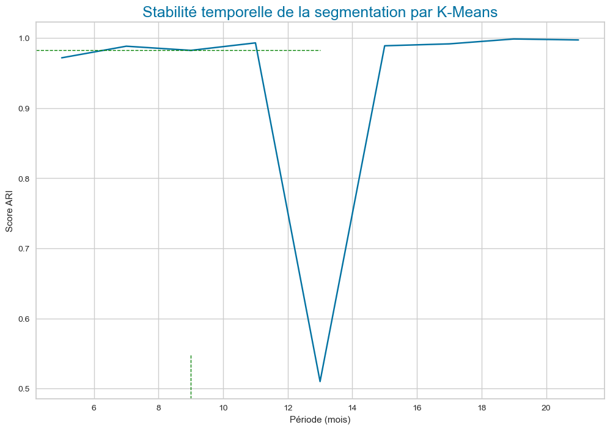

```python
ari_score = pd.DataFrame(ari_score, columns=["periode", "ARI"])

# plot ARI Score
fig = plt.figure(figsize=(12,8))
sns.lineplot(data=ari_score, x="periode", y="ARI")
plt.axhline(y=ari_score.iloc[2][1], linestyle="--",
            color="green",
            xmax=0.5,
            linewidth=1)
plt.axvline(x=ari_score.iloc[2][0], linestyle="--",
            color="green",
            ymax=1.1-(ari_score.iloc[2][1]),
            linewidth=1)
plt.xlabel("Période (mois)")
plt.ylabel("Score ARI")
plt.title("Stabilité temporelle de la segmentation par K-Means",
          fontsize=18,
          color="b")
plt.show()
```

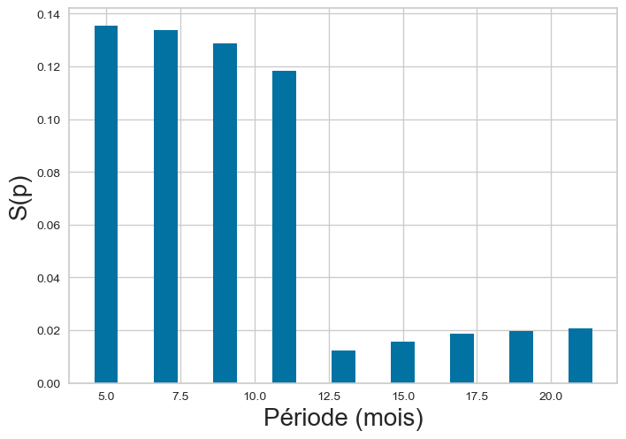

```python
# Plotting a bar graph to compare the results
p = [5, 7, 9, 11, 13, 15, 17, 19, 21 ]
plt.bar(p, silhouette_scores)
plt.xlabel('Période (mois)', fontsize = 20)
plt.ylabel('S(p)', fontsize = 20)
plt.show()
```

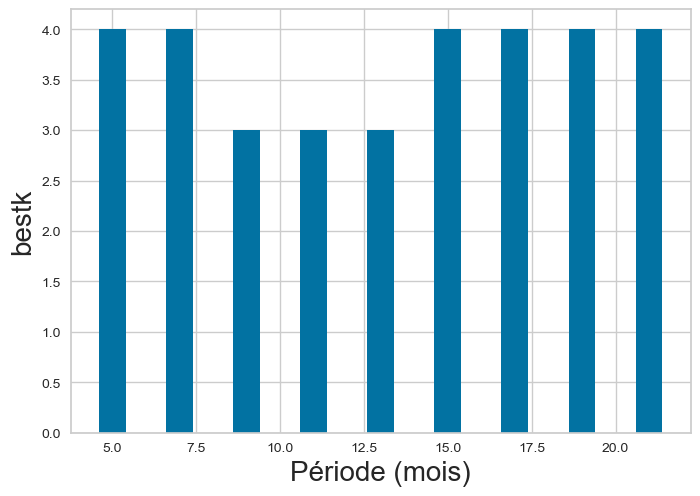

```python
# Plotting a bar graph to compare the results
p = [5, 7, 9, 11, 13, 15, 17, 19, 21]
plt.bar(p, bestk)
plt.xlabel('Période (mois)', fontsize = 20)
plt.ylabel('bestk', fontsize = 20)
plt.show()
```

# Conclusion et perspectives

Nous avons segmenté notre dataset clients en utilisant les algorithmes K-Means et DBSCAN, les resultats tournent autour de 3 à 5 clusters, mais le plus probant est le modele K-Means qui donne des clusters bien définis et distincts. Par ailleurs, La réduction de dimension ne perturbe pas la segmentation, permet de réduire le nombre de variables mais dégrade légèrement le silhouette-score. Avec notre modèle, l' analyse en composantes principales n'est pas indispensable, mais il faudrait s'y résoudre si on complexifiait le modèle avec un ajout conséquent de variables. Je propose quelques perspectives d'approfondissement du modèle:

- Analyse textuelle des commentaires clients pour mieux évaluer la satisfaction.
- Ajouter des variables: catégorie de produits achetés.
- Ajouter les valeurs extrêmes au modèle ou les traiter séparément